# Transfer Learning on Google Colab

## Classifying Flower Images

### Author: Tahmidul Islam

Date: 11/27/2020

When there is not a tons of training data is available moreover number of class is large, it is difficult to train a large deep learning model. Large deep learning models has hundred of thousands of parameters which requires lots of data to fine tune. Transfer learning is an excellent way to handle this type of problem. In transfer learning, we generally use a pre-trained model on a very large set and utilize the model architecture and estimated parameters. We discuss three modifications:

- Initialize with pretrained Resnet 34 and estimate all the parameters using flower training data
- Initialize with pretrained Resnet 34 and estimate all the parameters using augmented flower training data using the cutout method
- Initialize with pretrained Resnet 34 and estimate only the final layer using flower training data with cutout modification

## Data

First we explore the provided Flower dataset. This dataset is provided by Maria-Elena Nilsback and Andrew Zisserman (http://www.robots.ox.ac.uk/~vgg/data/flowers/102/). It contains color images of 102 different types of flowers. Our task is to predict the category of the flower given an image of a flower.

```python
# Read the text files containing filenames and labels.
import os
import pandas as pd
import numpy as np

dirname = "/content/drive/MyDrive/Colab Notebooks/fellowship/oxford-102-flowers"
trainName = pd.read_table(dirname + "/train.txt", sep = ' ', header = None, names = ['fileName', 'label'])
testName = pd.read_table(dirname + "/test.txt", sep = ' ', header = None, names = ['fileName', 'label'])
validName = pd.read_table(dirname + "/valid.txt", sep = ' ', header = None, names = ['fileName', 'label'])
```

```python
trainName.head()
testName.head()
validName.head()
```

|  | fileName | label |
| --- | --- | --- |
| 0 | jpg/image_04467.jpg | 89 |
| 1 | jpg/image_07129.jpg | 44 |
| 2 | jpg/image_05166.jpg | 4 |
| 3 | jpg/image_07002.jpg | 34 |
| 4 | jpg/image_02007.jpg | 79 |

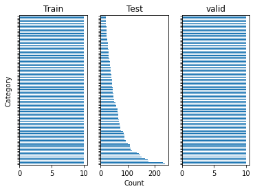

```python
import matplotlib.pyplot as plt
%matplotlib inline

fig = plt.figure()


# Divide the figure into a 2x1 grid, and give me the first section
a1 = fig.add_subplot(131)

trainName["label"].value_counts().plot(kind = 'barh', ax = a1)
plt.ylabel('Category')
a1.set_yticklabels([])
plt.title('Train')

a2 = fig.add_subplot(132)

testName["label"].value_counts().plot(kind = 'barh', ax = a2)
plt.xlabel('Count')
a2.set_yticklabels([])
plt.title('Test')


a3 = fig.add_subplot(133)

validName["label"].value_counts().plot(kind = 'barh', ax = a3)
a3.set_yticklabels([])
plt.title('valid')


fig.show()
```

We see the training and validation set as 10 images per class where the test data has imbalance. All the training, testing and validation images are in one folder 'jpg'. We need to create root folders 'train', 'test' and 'valid' and create subfolders corresponding to their label.

```
# Run this just once to create folder structure
from shutil import copyfile

filename = os.listdir(dirname + '/jpg')
for i in filename:
  name = 'jpg/' + i
  cname = os.path.join(dirname, name)
  if name in pd.Series.tolist(trainName["fileName"]):
    glab = trainName[trainName['fileName'] == name]['label']
    dname = os.path.join(dirname, 'train', str(int(glab)), str(i))
    copyfile(cname, dname)

testName = pd.read_table(dirname + "/test.txt", sep = ' ', header = None, names = ['fileName', 'label'])
for i in filename:
  name = 'jpg/' + i
  cname = os.path.join(dirname, name)
  if name in pd.Series.tolist(testName["fileName"]):
    glab = testName[testName['fileName'] == name]['label']
    dname = os.path.join(dirname, 'test', str(int(glab)), str(i))
    copyfile(cname, dname)

validName = pd.read_table(dirname + "/valid.txt", sep = ' ', header = None, names = ['fileName', 'label'])
for i in filename:
  name = 'jpg/' + i
  cname = os.path.join(dirname, name)
  if name in pd.Series.tolist(validName["fileName"]):
    glab = validName[validName['fileName'] == name]['label']
    dname = os.path.join(dirname, 'valid', str(int(glab)), str(i))
    copyfile(cname, dname)
```

## Transfer learning: Resnet 34

We use the pre-trained model Resnet 34 to perform image classification. Here, we intialize with Resnet 34 which was trained on Imagenet 1000. After initialization we have a fully connected final layer corresponding to our flower dataset.

## Data processing

We use the Imageloader of Pytorch to load the data. Random resize, crop and normalization have been applied to preprocess the data.

```python
# License: BSD
# Author: Sasank Chilamkurthy

from __future__ import print_function, division

import torch
import torch.nn as nn
import torch.optim as optim
from torch.optim import lr_scheduler
import numpy as np
import torchvision
from torchvision import datasets, models, transforms
import time
import os
import copy

plt.ion()   # interactive mode
```

```python
# Data augmentation and normalization for training
# Just normalization for validation
data_transforms = {
    'train': transforms.Compose([
        transforms.RandomResizedCrop(224),
        transforms.RandomHorizontalFlip(),
        transforms.ToTensor(),
        transforms.Normalize([0.485, 0.456, 0.406], [0.229, 0.224, 0.225])
    ]),
    'test': transforms.Compose([
        transforms.Resize(256),
        transforms.CenterCrop(224),
        transforms.ToTensor(),
        transforms.Normalize([0.485, 0.456, 0.406], [0.229, 0.224, 0.225])
    ]),
    'valid': transforms.Compose([
        transforms.Resize(256),
        transforms.CenterCrop(224),
        transforms.ToTensor(),
        transforms.Normalize([0.485, 0.456, 0.406], [0.229, 0.224, 0.225])
    ]),
}

data_dir = "/content/drive/MyDrive/Colab Notebooks/fellowship/oxford-102-flowers"
image_datasets = {x: datasets.ImageFolder(os.path.join(data_dir, x),
                                          data_transforms[x])
                  for x in ['train', 'test', 'valid']}
dataloaders = {x: torch.utils.data.DataLoader(image_datasets[x], batch_size=4,
                                             shuffle=True, num_workers=4)
              for x in ['train', 'test', 'valid']}
dataset_sizes = {x: len(image_datasets[x]) for x in ['train', 'test', 'valid']}
class_names = image_datasets['train'].classes

#device = torch.device("cuda:0" if torch.cuda.is_available() else "cpu")
device = torch.device('cuda')
```

Let's visualize few training images.

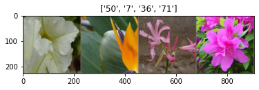

```python
def imshow(inp, title=None):
    """Imshow for Tensor."""
    inp = inp.numpy().transpose((1, 2, 0))
    mean = np.array([0.485, 0.456, 0.406])
    std = np.array([0.229, 0.224, 0.225])
    inp = std * inp + mean
    inp = np.clip(inp, 0, 1)
    plt.imshow(inp)
    if title is not None:
        plt.title(title)
    plt.pause(0.001)  # pause a bit so that plots are updated


# Get a batch of training data
inputs, classes = next(iter(dataloaders['train']))

# Make a grid from batch
out = torchvision.utils.make_grid(inputs)

imshow(out, title=[class_names[x] for x in classes])
```

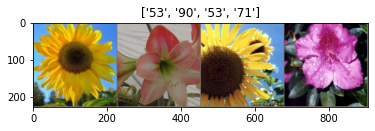

```python
# Get a batch of training data
inputs, classes = next(iter(dataloaders['test']))

# Make a grid from batch
out = torchvision.utils.make_grid(inputs)

imshow(out, title=[class_names[x] for x in classes])
```

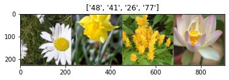

```python
# Get a batch of training data
inputs, classes = next(iter(dataloaders['valid']))

# Make a grid from batch
out = torchvision.utils.make_grid(inputs)

imshow(out, title=[class_names[x] for x in classes])
```

## Model

```python
def train_model(model, criterion, optimizer, scheduler, num_epochs=25):
    since = time.time()

    best_model_wts = copy.deepcopy(model.state_dict())
    best_acc = 0.0

    for epoch in range(num_epochs):
        print('Epoch {}/{}'.format(epoch, num_epochs - 1))
        print('-' * 10)

        # Each epoch has a training and validation phase
        for phase in ['train', 'test', 'valid']:
            if phase == 'train':
                model.train()  # Set model to training mode
            else:
                model.eval()   # Set model to evaluate mode

            running_loss = 0.0
            running_corrects = 0

            # Iterate over data.
            for inputs, labels in dataloaders[phase]:
                inputs = inputs.to(device)
                labels = labels.to(device)

                # zero the parameter gradients
                optimizer.zero_grad()

                # forward
                # track history if only in train
                with torch.set_grad_enabled(phase == 'train'):
                    outputs = model(inputs)
                    _, preds = torch.max(outputs, 1)
                    loss = criterion(outputs, labels)

                    # backward + optimize only if in training phase
                    if phase == 'train':
                        loss.backward()
                        optimizer.step()

                # statistics
                running_loss += loss.item() * inputs.size(0)
                running_corrects += torch.sum(preds == labels.data)
            if phase == 'train':
                scheduler.step()

            epoch_loss = running_loss / dataset_sizes[phase]
            epoch_acc = running_corrects.double() / dataset_sizes[phase]

            print('{} Loss: {:.4f} Acc: {:.4f}'.format(
                phase, epoch_loss, epoch_acc))

            # deep copy the model
            if phase == 'valid' and epoch_acc > best_acc:
                best_acc = epoch_acc
                best_model_wts = copy.deepcopy(model.state_dict())

        print()

    time_elapsed = time.time() - since
    print('Training complete in {:.0f}m {:.0f}s'.format(
        time_elapsed // 60, time_elapsed % 60))
    print('Best val Acc: {:4f}'.format(best_acc))

    # load best model weights
    model.load_state_dict(best_model_wts)
    return model
```

```python
def visualize_model(model, num_images=6):
    was_training = model.training
    model.eval()
    images_so_far = 0
    fig = plt.figure()

    with torch.no_grad():
        for i, (inputs, labels) in enumerate(dataloaders['test']):
            inputs = inputs.to(device)
            labels = labels.to(device)

            outputs = model(inputs)
            _, preds = torch.max(outputs, 1)

            for j in range(inputs.size()[0]):
                images_so_far += 1
                ax = plt.subplot(num_images//2, 2, images_so_far)
                ax.axis('off')
                ax.set_title('predicted: {}'.format(class_names[preds[j]]))
                imshow(inputs.cpu().data[j])

                if images_so_far == num_images:
                    model.train(mode=was_training)
                    return
        model.train(mode=was_training)
```

```python
model_ft = models.resnet34(pretrained=True)
num_ftrs = model_ft.fc.in_features
# Here the size of each output sample is set to 2.
# Alternatively, it can be generalized to nn.Linear(num_ftrs, len(class_names)).
model_ft.fc = nn.Linear(num_ftrs, len(class_names))

model_ft = model_ft.to(device)

criterion = nn.CrossEntropyLoss()

# Observe that all parameters are being optimized
optimizer_ft = optim.SGD(model_ft.parameters(), lr=0.001, momentum=0.9)

# Decay LR by a factor of 0.1 every 7 epochs
exp_lr_scheduler = lr_scheduler.StepLR(optimizer_ft, step_size=5, gamma=0.1)
```

```
Downloading: "https://download.pytorch.org/models/resnet34-333f7ec4.pth" to /root/.cache/torch/hub/checkpoints/resnet34-333f7ec4.pth
```

```python
model_ft = train_model(model_ft, criterion, optimizer_ft, exp_lr_scheduler,
                       num_epochs=25)
```

```
----------
train Loss: 4.4465 Acc: 0.0529
test Loss: 3.1548 Acc: 0.2678
valid Loss: 3.1261 Acc: 0.2706

----------
train Loss: 3.2098 Acc: 0.2451
test Loss: 1.9403 Acc: 0.5274
valid Loss: 1.7505 Acc: 0.5725

----------
train Loss: 2.2922 Acc: 0.4657
test Loss: 1.3647 Acc: 0.6502
valid Loss: 1.1395 Acc: 0.7000

----------
train Loss: 1.7759 Acc: 0.6000
test Loss: 1.0276 Acc: 0.7292
valid Loss: 0.9069 Acc: 0.7578

----------
train Loss: 1.3783 Acc: 0.6873
test Loss: 0.7707 Acc: 0.7920
valid Loss: 0.6079 Acc: 0.8324

----------
train Loss: 1.0629 Acc: 0.7843
test Loss: 0.6896 Acc: 0.8190
valid Loss: 0.5361 Acc: 0.8608

----------
train Loss: 0.9705 Acc: 0.8108
test Loss: 0.6425 Acc: 0.8336
valid Loss: 0.5165 Acc: 0.8529

----------
train Loss: 0.8774 Acc: 0.8480
test Loss: 0.6061 Acc: 0.8445
valid Loss: 0.4765 Acc: 0.8608

```

[output cut: 72 more lines]

```
test Loss: 0.5574 Acc: 0.8538
valid Loss: 0.4267 Acc: 0.8794

----------
train Loss: 0.8174 Acc: 0.8451
test Loss: 0.5177 Acc: 0.8637
valid Loss: 0.4089 Acc: 0.8873

----------
train Loss: 0.7650 Acc: 0.8735
test Loss: 0.5715 Acc: 0.8488
valid Loss: 0.4413 Acc: 0.8814

Training complete in 49m 2s
Best val Acc: 0.891176
```

We get accuracy about 89% with the pretrained model.

```python
visualize_model(model_ft)
```

[output not shown]

## Cropout for regularization

Furthermore, we apply the cropout regularization technique which augments the dataset by randomly removing patches from the image. We choose the number of patch to be 01 and the size of the patch to be 50 pixels.

```python
# cutout function
import torch
import numpy as np


class Cutout(object):
    """Randomly mask out one or more patches from an image.
    Args:
        n_holes (int): Number of patches to cut out of each image.
        length (int): The length (in pixels) of each square patch.
    """
    def __init__(self, n_holes, length):
        self.n_holes = n_holes
        self.length = length

    def __call__(self, img):
        """
        Args:
            img (Tensor): Tensor image of size (C, H, W).
        Returns:
            Tensor: Image with n_holes of dimension length x length cut out of it.
        """
        h = img.size(1)
        w = img.size(2)

        mask = np.ones((h, w), np.float32)

        for n in range(self.n_holes):
            y = np.random.randint(h)
            x = np.random.randint(w)

            y1 = np.clip(y - self.length // 2, 0, h)
            y2 = np.clip(y + self.length // 2, 0, h)
            x1 = np.clip(x - self.length // 2, 0, w)
            x2 = np.clip(x + self.length // 2, 0, w)

            mask[y1: y2, x1: x2] = 0.

        mask = torch.from_numpy(mask)
        mask = mask.expand_as(img)
        img = img * mask

        return img
```

```python
# Data augmentation and normalization for training
# Just normalization for validation
data_transforms = {
    'train': transforms.Compose([
        transforms.RandomResizedCrop(224),
        transforms.RandomHorizontalFlip(),
        transforms.ToTensor(),
        transforms.Normalize([0.485, 0.456, 0.406], [0.229, 0.224, 0.225]),
        Cutout(n_holes= 1, length= 50)
    ]),
    'test': transforms.Compose([
        transforms.Resize(256),
        transforms.CenterCrop(224),
        transforms.ToTensor(),
        transforms.Normalize([0.485, 0.456, 0.406], [0.229, 0.224, 0.225])
    ]),
    'valid': transforms.Compose([
        transforms.Resize(256),
        transforms.CenterCrop(224),
        transforms.ToTensor(),
        transforms.Normalize([0.485, 0.456, 0.406], [0.229, 0.224, 0.225])
    ]),
}

image_datasets = {x: datasets.ImageFolder(os.path.join(data_dir, x),
                                          data_transforms[x])
                  for x in ['train', 'test', 'valid']}
dataloaders = {x: torch.utils.data.DataLoader(image_datasets[x], batch_size=4,
                                             shuffle=True, num_workers=4)
              for x in ['train', 'test', 'valid']}
dataset_sizes = {x: len(image_datasets[x]) for x in ['train', 'test', 'valid']}
```

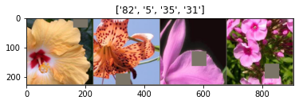

```python
# Get a batch of training data
inputs, classes = next(iter(dataloaders['train']))

# Make a grid from batch
out = torchvision.utils.make_grid(inputs)

imshow(out, title=[class_names[x] for x in classes])
```

```python
model_ft = train_model(model_ft, criterion, optimizer_ft, exp_lr_scheduler, num_epochs=25)
```

```
----------
train Loss: 0.9002 Acc: 0.8412
test Loss: 0.5833 Acc: 0.8489
valid Loss: 0.4575 Acc: 0.8716

----------
train Loss: 0.8470 Acc: 0.8588
test Loss: 0.6244 Acc: 0.8423
valid Loss: 0.4930 Acc: 0.8667

----------
train Loss: 0.8600 Acc: 0.8539
test Loss: 0.5950 Acc: 0.8450
valid Loss: 0.4693 Acc: 0.8765

----------
train Loss: 0.8725 Acc: 0.8451
test Loss: 0.5677 Acc: 0.8520
valid Loss: 0.4519 Acc: 0.8775

----------
train Loss: 0.8382 Acc: 0.8637
test Loss: 0.5764 Acc: 0.8517
valid Loss: 0.4590 Acc: 0.8686

----------
train Loss: 0.8493 Acc: 0.8598
test Loss: 0.5670 Acc: 0.8579
valid Loss: 0.4519 Acc: 0.8794

----------
train Loss: 0.8254 Acc: 0.8657
test Loss: 0.5914 Acc: 0.8471
valid Loss: 0.4757 Acc: 0.8598

----------
train Loss: 0.8875 Acc: 0.8480
test Loss: 0.5684 Acc: 0.8505
valid Loss: 0.4426 Acc: 0.8745

```

[output cut: 72 more lines]

```
test Loss: 0.5598 Acc: 0.8531
valid Loss: 0.4488 Acc: 0.8667

----------
train Loss: 0.8331 Acc: 0.8578
test Loss: 0.6012 Acc: 0.8453
valid Loss: 0.4772 Acc: 0.8667

----------
train Loss: 0.8647 Acc: 0.8569
test Loss: 0.5909 Acc: 0.8488
valid Loss: 0.4533 Acc: 0.8735

Training complete in 33m 45s
Best val Acc: 0.884314
```

With random crop out and retraining the Resnet, we get similar accuracy.

## Freezing Resnet parameters

```python
model_conv = torchvision.models.resnet34(pretrained=True)
for param in model_conv.parameters():
    param.requires_grad = False

# Parameters of newly constructed modules have requires_grad=True by default
num_ftrs = model_conv.fc.in_features
model_conv.fc = nn.Linear(num_ftrs, len(class_names))

model_conv = model_conv.to(device)

criterion = nn.CrossEntropyLoss()

# Observe that only parameters of final layer are being optimized as
# opposed to before.
optimizer_conv = optim.SGD(model_conv.fc.parameters(), lr=0.001, momentum=0.9)

# Decay LR by a factor of 0.1 every 7 epochs
exp_lr_scheduler = lr_scheduler.StepLR(optimizer_conv, step_size=7, gamma=0.1)
```

```python
model_conv = train_model(model_conv, criterion, optimizer_conv,
                         exp_lr_scheduler, num_epochs=25)
```

```
----------
train Loss: 4.7421 Acc: 0.0196
test Loss: 4.0604 Acc: 0.1142
valid Loss: 4.0029 Acc: 0.1480

----------
train Loss: 4.0835 Acc: 0.0951
test Loss: 3.3804 Acc: 0.2628
valid Loss: 3.2409 Acc: 0.3059

----------
train Loss: 3.4851 Acc: 0.2304
test Loss: 2.8255 Acc: 0.3971
valid Loss: 2.6104 Acc: 0.4608

----------
train Loss: 3.1260 Acc: 0.3382
test Loss: 2.2418 Acc: 0.5269
valid Loss: 2.1874 Acc: 0.5402

----------
train Loss: 2.7415 Acc: 0.4118
test Loss: 1.9945 Acc: 0.5972
valid Loss: 1.8654 Acc: 0.6176

----------
train Loss: 2.4325 Acc: 0.4833
test Loss: 1.7757 Acc: 0.6040
valid Loss: 1.6807 Acc: 0.6147

----------
train Loss: 2.2275 Acc: 0.5373
test Loss: 1.6299 Acc: 0.6503
valid Loss: 1.4586 Acc: 0.7010

----------
train Loss: 1.9686 Acc: 0.6637
test Loss: 1.4559 Acc: 0.7161
valid Loss: 1.3294 Acc: 0.7618

```

[output cut: 72 more lines]

```
test Loss: 1.2664 Acc: 0.7551
valid Loss: 1.1688 Acc: 0.7892

----------
train Loss: 1.8159 Acc: 0.6990
test Loss: 1.2814 Acc: 0.7626
valid Loss: 1.1867 Acc: 0.7765

----------
train Loss: 1.7937 Acc: 0.7176
test Loss: 1.2534 Acc: 0.7494
valid Loss: 1.1595 Acc: 0.7745

Training complete in 30m 56s
Best val Acc: 0.789216
```

## Conclusion

[output not shown]

## Reference

- Angelova, A., Zhu, S., & Lin, Y. (2013, January). Image segmentation for large-scale subcategory flower recognition. In 2013 IEEE Workshop on Applications of Computer Vision (WACV) (pp. 39-45). IEEE.
- Paszke, A., Gross, S., Massa, F., Lerer, A., Bradbury, J., Chanan, G., ... & Desmaison, A. (2019). Pytorch: An imperative style, high-performance deep learning library. In Advances in neural information processing systems (pp. 8026-8037).
- Wu, Y., Chen, Y., Wang, L., Ye, Y., Liu, Z., Guo, Y., & Fu, Y. (2019). Large scale incremental learning. In Proceedings of the IEEE Conference on Computer Vision and Pattern Recognition (pp. 374-382).
- Hou, W., Wang, W., Liu, R. Z., & Lu, T. (2019, July). Cropout: A General Mechanism for Reducing Overfitting on Convolutional Neural Networks. In 2019 International Joint Conference on Neural Networks (IJCNN) (pp. 1-8). IEEE.